# Relatório 3 - Estatística

Fazendo algumas análises em R

Artur Papa - 3886

Erian Alves - 3862

Guilherme Sergio - 3854

Sumário

# 1 Dados

A seguir é feita a leitura do conjunto de dados a ser utilizado na atividade. Os dados são referentes ao contexto de aplicação de fertilantes em produções e a possível presença de pragas.

Obs.: Temos dois caminhos de dados diferentes devido ao fato de um integrante do grupo ter feito o trabalho de um diretório criado no notebook, enquanto que o outro se trata do caminho do repositório clonado do GitHub. Caso dê erro em um dos caminhos, basta comentá-lo e descomentar o que não está selecionado.

```r
df <- read.csv("~/Downloads/dados_atividade1.xlsx - Planilha1.csv")
#head(df)
```

```r
df <- read.csv("~/GitHub/MAF261-Experimental_Statistics/relatorio3/dados_atividade1.xlsx - Planilha1.csv")
```

```
## Error in file(file, "rt"): não é possível abrir a conexão
```

```r
head(df)
```

```
##   ID Producao Praga Fertilizante
## 1  1      388     1            A
## 2  2      454     0            A
## 3  3      812     0            A
## 4  4      514     1            A
## 5  5      526     0            A
## 6  6      843     0            A
```

A partir da visualização do conjunto de dados a ser utilizado, é possível observar que o dataset é composto por 4 colunas: uma para o id (ID) da instância do dado, uma referente ao valor da produção (Producao), uma para indicar se houve a presença ou não de pragas (Praga) naquela produção e uma para informar qual o tipo de fertilizante empregado.

Tem-se por intuito, inicialmente, realizar análises com base nos fertilizantes para os valores de produção, logo que há diferentes tratamentos sendo aplicados.

```r
#install.packages("daewr")
library("daewr")
library("kableExtra")
kable(df, align='c')
```

| ID | Producao | Praga | Fertilizante |
| --- | --- | --- | --- |
| 1 | 388 | 1 | A |
| 2 | 454 | 0 | A |
| 3 | 812 | 0 | A |
| 4 | 514 | 1 | A |
| 5 | 526 | 0 | A |
| 6 | 843 | 0 | A |
| 7 | 1042 | 0 | B |
| 8 | 697 | 0 | B |
| 9 | 813 | 1 | B |
| 10 | 861 | 0 | B |
| 11 | 1195 | 1 | B |
| 12 | 1022 | 1 | B |
| 13 | 280 | 1 | C |
| 14 | 222 | 0 | C |
| 15 | 89 | 0 | C |
| 16 | 557 | 1 | C |
| 17 | 300 | 0 | C |
| 18 | 55 | 0 | C |
| 19 | 640 | 0 | D |
| 20 | 405 | 1 | D |
| 21 | 286 | 1 | D |
| 22 | 456 | 0 | D |
| 23 | 295 | 0 | D |
| 24 | 354 | 0 | D |

# 2 Descritivas

De maneira a se desenvolver um entendimento inicial dos dados dispostos, foi realizada algumas análises descritivas dos dados, apresentadas a seguir.

```r
library(tidyverse)
df |> group_by(Fertilizante) |>
  summarise(media=mean(Producao), desv.pad=sd(Praga))|>
  kable(align='c', digits=2)
```

| Fertilizante | media | desv.pad |
| --- | --- | --- |
| A | 589.50 | 0.52 |
| B | 938.33 | 0.55 |
| C | 250.50 | 0.52 |
| D | 406.00 | 0.52 |

- A partir das informações das médias das produções para cada tipo de tratamento expostas acima, tem-se uma suspeita de que, aparentemente, existe alguma diferença entre os tratamentos.
- Ao se observar o gráfico abaixo, tal suspeita torna-se mais concreta, visto que as médias entre os experimentos estão bem diferentes. É possível observar que o tratamento B apresenta valores de produção superiores aos restantes, enquanto o tratamento C consiste dos valores mais baixos.
- Uma maneira de identificar se existe alguma diferença significativa entre as médias é por meio da realização de um teste ANOVA.

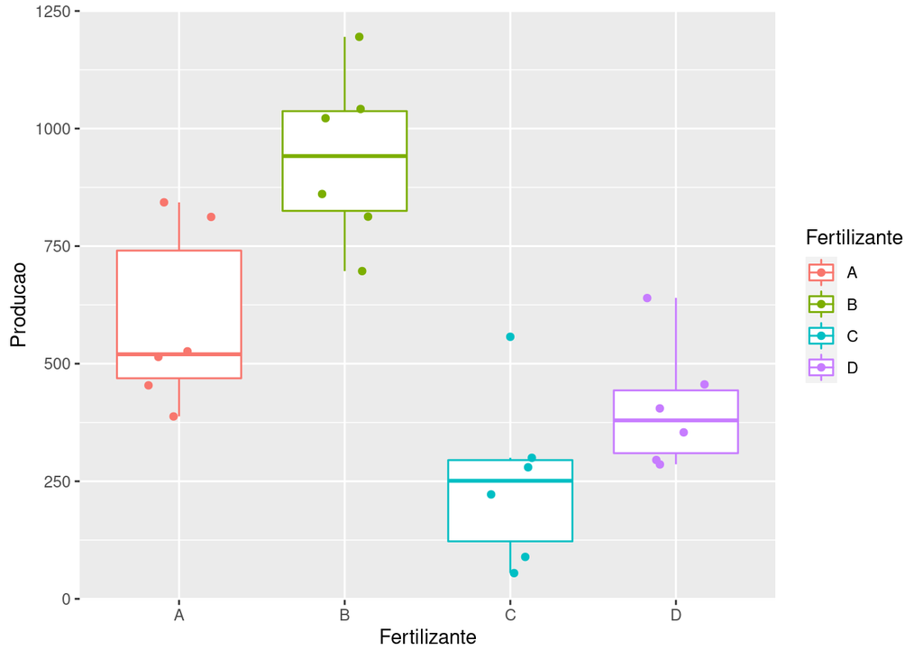

```r
df |> ggplot(aes(x=Fertilizante, y=Producao, color=Fertilizante)) +
  geom_boxplot(outlier.shape=NA) +
  geom_jitter(width=0.2)
```

# 3 ANOVA

Como queremos verificar se existe alguma diferença entre os tratamentos, utilizando a notação de testes de hipótese, o que desejamos testar pode ser representado da seguinte maneira:
$$H_0: \mu_{A} = \mu_{B} = \mu_{C} =
\mu_{D}$$
Ou seja, a hipótese nula dos dados é que todas as médias de produção para os diferentes fertilizantes são iguais. Aplicando a anova:

```r
m <- aov(Producao ~ Fertilizante, data = df)
summary(m)
```

```
##              Df  Sum Sq Mean Sq F value   Pr(>F)
## Fertilizante  3 1576427  525476   17.66 7.66e-06 ***
## Residuals    20  595078   29754
## ---
## Signif. codes:  0 '***' 0.001 '**' 0.01 '*' 0.05 '.' 0.1 ' ' 1
```

A partir das informações fornecidas com a aplicação da ANOVA, foi encontrado como p-valor o resultado 7.66e-06. Trata-se de um valor bem menor ao nível de significância estabelecido para o teste, indicado que há evidência para rejeitar a hipótese nula. Considerando isso, a suspeita anterior de que haveria uma diferença entre as médias das produções para os diferentes tratamentos é confirmada pelo teste.

# 4 Pressupostos

Em relação ao teste aplicado previamente, é importante comentar sobre as suposições realizadas para sua aplicação seja válida: - Populações normalmente distribuídas; - Populações tem mesma variância; - Amostras são aleatórias e mutuamente independentes;

Já abordando sobre os resíduos, podemos observar como eles se comportam.

O modelo que estamos considerando diz que uma observação de uma produção para um dado tratamento é igual a média para aquele tratamento somado ao seu respectivo resíduo, como é mostrado a seguir:
$$y_{ij} = \mu_i + \epsilon_{ij}$$
Partindo disto, pode-se definir o resíduo como o valor da observação menor a média amostral do tratamento. A expressão é apresentada a seguir:
$$e_{ij} = y_{ij} - \bar{y}_{i\cdot}$$

```r
residuo <- m$residuals
dado <- data.frame(id=1:12, residuo=residuo)
kable(dado)
```

| id | residuo |
| --- | --- |
| 1 | -201.50000 |
| 2 | -135.50000 |
| 3 | 222.50000 |
| 4 | -75.50000 |
| 5 | -63.50000 |
| 6 | 253.50000 |
| 7 | 103.66667 |
| 8 | -241.33333 |
| 9 | -125.33333 |
| 10 | -77.33333 |
| 11 | 256.66667 |
| 12 | 83.66667 |
| 1 | 29.50000 |
| 2 | -28.50000 |
| 3 | -161.50000 |
| 4 | 306.50000 |
| 5 | 49.50000 |
| 6 | -195.50000 |
| 7 | 234.00000 |
| 8 | -1.00000 |
| 9 | -120.00000 |
| 10 | 50.00000 |
| 11 | -111.00000 |
| 12 | -52.00000 |

Na exposição acima é possível realizar uma observação inicial quanto aos resíduos encontrados pela ANOVA.

## 4.1 Resíduo versus tratamento

```r
plot(m, which=5, pch=19)
```

[output not shown]

## 4.2 Resíduo versus valor ajustado

Como o modelo é
$$y_{ij}=\mu_i+\epsilon_{ij},\;\;\;\;\;
\epsilon_{ij}\sim N(0, \sigma^2)$$
então o valor ajustado é
$$\hat{y}_{ij}=\bar{y}_{i\cdot}$$

```r
library(tidyverse)
df |> group_by(Fertilizante) |>
  summarise(media = mean(Producao), desv.pad = sd(Producao)) |>
  kable(align='c', digits=2)
```

| Fertilizante | media | desv.pad |
| --- | --- | --- |
| A | 589.50 | 191.03 |
| B | 938.33 | 180.86 |
| C | 250.50 | 180.21 |
| D | 406.00 | 131.67 |

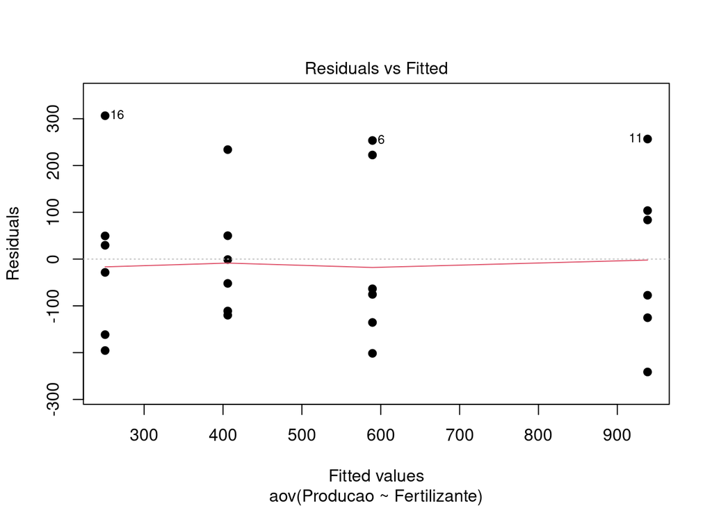

```r
plot(m, which=1, pch=19)
```

Analisando o gráfico é possível observar levemente que os resíduos estão distribuidos aleatoriamente e também que aparentemente a variância deles é parceida. Os pontos apresentam uma certa aleatoriedade nos dois “lados” de 0, um bom comportamento.

## 4.3 Normalidade dos resíduos

A normalidade dos resíduos é um pressuposto importante para o estudo das médias dos tratamentos utilizando a ANOVA. Para realizar uma análise referente a eles, pode-se utilizar um gráfico ggplot. Nele, para se observar a normalidade dos resíduos, os valores devem seguir uma relação linear e estarem próximos da reta presente no gráfico.

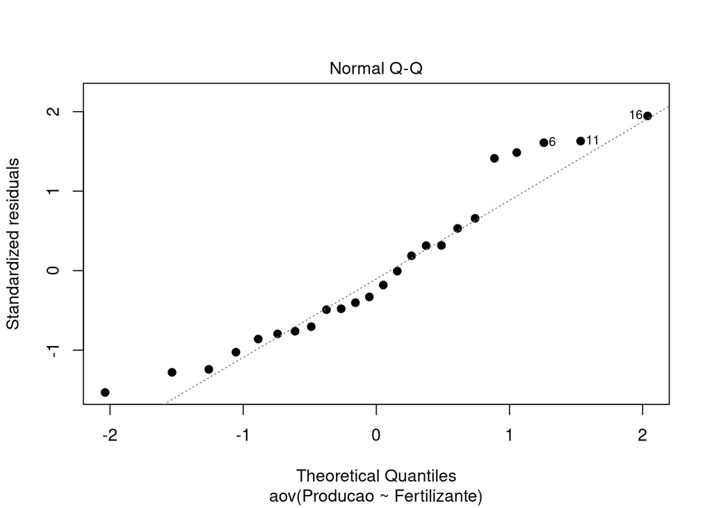

```r
plot(m, which=2, pch = 19)
```

Para auxiliar na análise, é possível utilizar o recurso de um envelope a ser desenhado no gráfico que irá indicar uma “faixa de normalidade”. Os pontos que fugirem da faixa podem apontar para uma falha na normalidade.

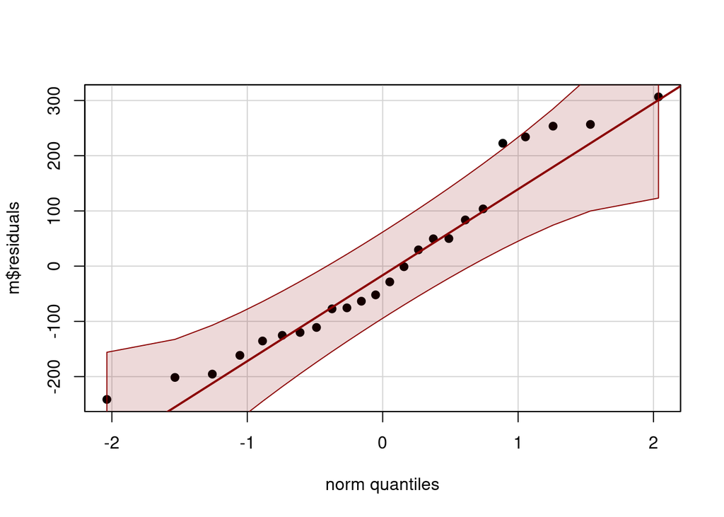

```r
library("car") # se necessário: install.packages("car")
qqPlot(m$residuals, pch=19, col.lines="darkred", id=F)
```

## 4.4 Testando a normalidade dos resíduos

O Teste de Shapiro-Wilk tem como objetivo avaliar se uma distribuição é semelhante a uma distribuição normal. A distribuição normal também pode ser chamada de gaussiana e sua forma assemelha-se a de um sino. Esse tipo de distribuição é muito importante, por ser frequentemente usada para modelar fenômenos naturais. Além disse, vale observar que para dizer que uma distribuição é normal, o valor p precisa ser maior do que 0.05.

Para testar a normalidade é possível aplicar o teste de Shapiro-Wilks. As hipóteses do teste são:

$$H_{0} = \text{Testes seguem uma
distribuição normal}\\
H_{1} = \text{Testes não seguem uma distribuição normal}$$

Aplicando o teste:

```r
shapiro.test(m$residuals)
```

```
##
##  Shapiro-Wilk normality test
##
## data:  m$residuals
## W = 0.93551, p-value = 0.1295
```

Com um nível de relevância p = 0.05, é possível observar que não temos evidências suficientes para rejeitar a hipótese nula, dessa forma podemos assumir que os dados são normais. O pressuposto para a normalidade dos resíduos é válido.

# 5 ANOVA para dados binários

## 5.1 Regressão Logística

Geralmente a regressão logística é usada para ajudar a criar previsões precisas. É semelhante à regressão linear, exceto que, em vez de um resultado gráfico, a variável de destino é binária, o valor é 0 ou 1.

Nesse caso, a regressão logística será usada para fazermos os dados da ANOVA de maneira binária, vale notar que além da regressão utilizada, quando aplicamos a ANOVA no nosso modelo usamos como teste “Chisq” que quer dizer “chi-squared”, ou seja, nessa análise de dados utilizamos do teste qui-quadrado para validarmos nosso resultado.

```r
modelo <- glm(Praga ~ Fertilizante, data = df, family = binomial(link = "logit"))
summary(modelo)
```

```
##
## Call:
## glm(formula = Praga ~ Fertilizante, family = binomial(link = "logit"),
##     data = df)
##
## Deviance Residuals:
##     Min       1Q   Median       3Q      Max
## -1.1774  -0.9005  -0.9005   1.2536   1.4823
##
## Coefficients:
##                 Estimate Std. Error z value Pr(>|z|)
## (Intercept)   -6.931e-01  8.660e-01  -0.800    0.423
## FertilizanteB  6.931e-01  1.190e+00   0.582    0.560
## FertilizanteC  4.079e-16  1.225e+00   0.000    1.000
## FertilizanteD  8.158e-16  1.225e+00   0.000    1.000
##
## (Dispersion parameter for binomial family taken to be 1)
##
##     Null deviance: 31.755  on 23  degrees of freedom
## Residual deviance: 31.232  on 20  degrees of freedom
## AIC: 39.232
##
## Number of Fisher Scoring iterations: 4
```

## 5.2 ANOVA

```r
anova(modelo, test = "Chisq")
```

```
## Analysis of Deviance Table
##
## Model: binomial, link: logit
##
## Response: Praga
##
## Terms added sequentially (first to last)
##
##
##              Df Deviance Resid. Df Resid. Dev Pr(>Chi)
## NULL                            23     31.755
## Fertilizante  3  0.52276        20     31.232   0.9139
```

# 6 Testes para homogeneidade na variância

### 6.0.1 F

É possível utilizar um teste F para comparar duas variâncias. As hipóteses para o teste F são:

$$H_{0} = \text{As variâncias são
iguais}\\ H_{1} = \text{As variâncias são diferentes}$$

#### Par a par

**A e B**

```r
var.test(Producao ~ Fertilizante, data=df[df$Fertilizante=="A" | df$Fertilizante=="B",])
```

```
##
##  F test to compare two variances
##
## data:  Producao by Fertilizante
## F = 1.1156, num df = 5, denom df = 5, p-value = 0.9074
## alternative hypothesis: true ratio of variances is not equal to 1
## 95 percent confidence interval:
##  0.156108 7.972555
## sample estimates:
## ratio of variances
##           1.115607
```

**A e C**

```r
var.test(Producao ~ Fertilizante, data=df[df$Fertilizante=="A" | df$Fertilizante=="C",])
```

```
##
##  F test to compare two variances
##
## data:  Producao by Fertilizante
## F = 1.1237, num df = 5, denom df = 5, p-value = 0.9013
## alternative hypothesis: true ratio of variances is not equal to 1
## 95 percent confidence interval:
##  0.1572403 8.0303850
## sample estimates:
## ratio of variances
##           1.123699
```

**A e D**

```r
var.test(Producao ~ Fertilizante, data=df[df$Fertilizante=="A" | df$Fertilizante=="D",])
```

```
##
##  F test to compare two variances
##
## data:  Producao by Fertilizante
## F = 2.105, num df = 5, denom df = 5, p-value = 0.4334
## alternative hypothesis: true ratio of variances is not equal to 1
## 95 percent confidence interval:
##   0.2945512 15.0429598
## sample estimates:
## ratio of variances
##           2.104976
```

**B e C**

```r
var.test(Producao ~ Fertilizante, data=df[df$Fertilizante=="C" | df$Fertilizante=="B",])
```

```
##
##  F test to compare two variances
##
## data:  Producao by Fertilizante
## F = 1.0073, num df = 5, denom df = 5, p-value = 0.9939
## alternative hypothesis: true ratio of variances is not equal to 1
## 95 percent confidence interval:
##  0.140946 7.198219
## sample estimates:
## ratio of variances
##           1.007254
```

**B e D**

```r
var.test(Producao ~ Fertilizante, data=df[df$Fertilizante=="D" | df$Fertilizante=="B",])
```

```
##
##  F test to compare two variances
##
## data:  Producao by Fertilizante
## F = 1.8868, num df = 5, denom df = 5, p-value = 0.5027
## alternative hypothesis: true ratio of variances is not equal to 1
## 95 percent confidence interval:
##   0.2640277 13.4841012
## sample estimates:
## ratio of variances
##           1.886843
```

**C e D**

```r
var.test(Producao ~ Fertilizante, data=df[df$Fertilizante=="C" | df$Fertilizante=="D",])
```

```
##
##  F test to compare two variances
##
## data:  Producao by Fertilizante
## F = 1.8733, num df = 5, denom df = 5, p-value = 0.5075
## alternative hypothesis: true ratio of variances is not equal to 1
## 95 percent confidence interval:
##   0.2621264 13.3869963
## sample estimates:
## ratio of variances
##           1.873255
```

Observando todos os testes par a par acima, é possível observar que aparentemente existe homogeniedade entre as variâncias. isso satisfaz um pressuposto importante da anova.

### Bartlett

```r
bartlett.test(Producao ~ Fertilizante, data=df)
```

```
##
##  Bartlett test of homogeneity of variances
##
## data:  Producao by Fertilizante
## Bartlett's K-squared = 0.70949, df = 3, p-value = 0.871
```

O teste de barlett ainda confirma isso.

# 7 Teste de tukey

Feita a anova e visto que existem pelo menos dois tratamentos com diferença significativa, é possível aplicar um teste para encontrar onde vem a diferença. O gráfico plotado na análise descritiva sugere uma diferença entre quase todos os tratamentos, resta saber quais são significantes.

```r
TukeyHSD(m)
```

```
##   Tukey multiple comparisons of means
##     95% family-wise confidence level
##
## Fit: aov(formula = Producao ~ Fertilizante, data = df)
##
## $Fertilizante
##          diff        lwr       upr     p adj
## B-A  348.8333   70.09003  627.5766 0.0110653
## C-A -339.0000 -617.74330  -60.2567 0.0137652
## D-A -183.5000 -462.24330   95.2433 0.2836445
## C-B -687.8333 -966.57663 -409.0900 0.0000059
## D-B -532.3333 -811.07663 -253.5900 0.0001702
## D-C  155.5000 -123.24330  434.2433 0.4218483
```

Analisando o resultado do teste de tukey, é possível perceber diversas diferenças. Com um nível de signifcância de 5%, o fertilizante B apresentou diferença significativa para todos os outros fertilizantes. Nesse sentido, podemos que o tratamento B apresentou uma melhora na produção estatisticamente significativa. O inverso não pode ser dito para o tratamento C. Ele apresenta a menor média, mas não temos evidências suficientes para mostrar uma diferença com o tratamento D.